# Simulation mit Hazard Ratios

Robin Denz

2024-09-09

# Vorbemerkungen

Ziel der Simulationen in diesem Dokument ist die Auswertungsmethodik besser zu verstehen und die von mir programmierte Implementierung dieser zu validieren. Es werden keine realistischen Werte verwendet, sondern lediglich irgendwelche Werte mit denen man die erwarteten Effekt beobachten kann.

Es werden zunächst 3 Simulationszenarien betrachtet, in denen es kein treatment-confounder feedback über die Zeit gibt. In diesen Fällen sollten die Ergebnisse aus einem einfachen Cox Modell mit zeitabhängigen Kovariaten mit denen des zeitabhängigen Matchings übereinstimmen. Dies wird überprüft bei:

- 1. Simulation ohne Confounding
- 2. Simulation mit zeit-konstantem Confounder
- 3. Simulation mit zeitabhängigem Confounder

Erst danach werden Simulationen mit treatment-confounder feedback durchgeführt. Dabei ist dann nicht mehr zu erwarten das die HRs aus den Cox Modellen gleich sind. Dies soll überprüft werden.

# Kein Confounding

Im ersten Schritt werden nur Daten zu MAC, Impfung und Influenza simuliert, ohne jede Form von Confounding.

```
## Lade nötigen Namensraum: ggforce
```

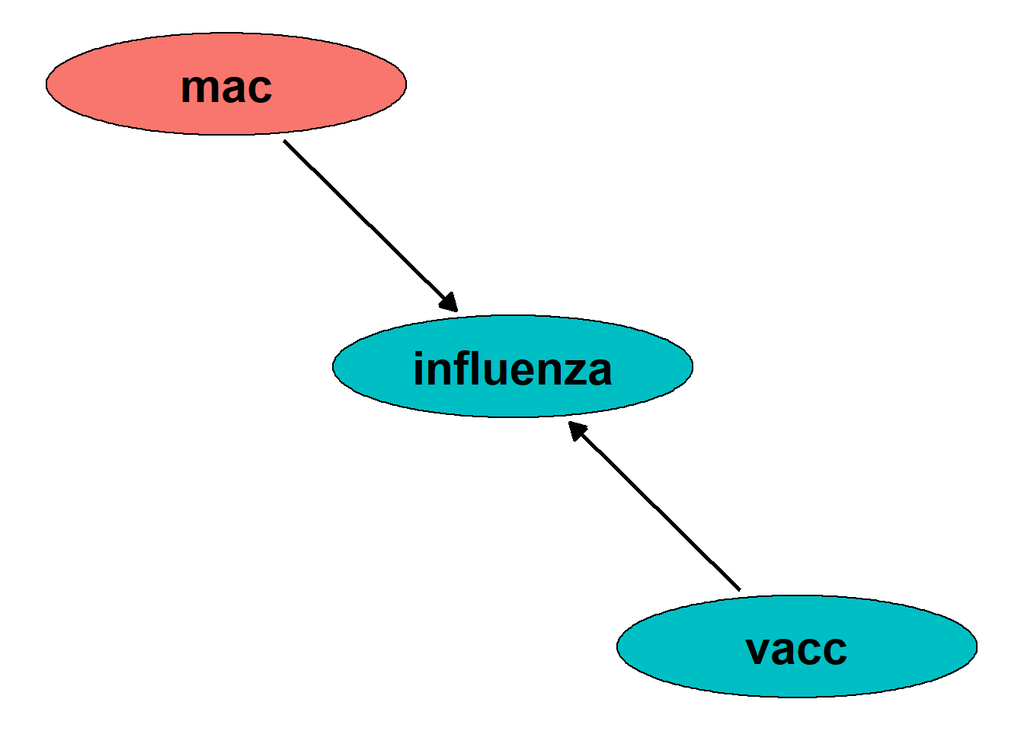

```r
prob_influ <- function(data, base_p, rr_mac, rr_vacc_mac, rr_vacc_nonmac) {
  base_p * rr_mac^(data$mac) * rr_vacc_mac^(data$mac & data$vacc_event) *
    rr_vacc_nonmac^(data$vacc_event & !data$mac)
}

dag <- empty_dag() +
  node("mac", type="rbernoulli", p=0.2) +
  node_td("vacc", type="time_to_event", prob_fun=0.001,
          event_duration=Inf) +
  node_td("influenza", type="time_to_event", prob_fun=prob_influ,
          event_duration=20, parents=c("mac", "vacc_event"),
          base_p=0.01, rr_mac=1.5, rr_vacc_mac=0.8, rr_vacc_nonmac=0.5)
plot(dag)
```

```r
summary(dag)
```

```
## A DAG object using the following structural equations:
##
##          mac ~ Bernoulli(0.2)
##      vacc(t) ~ Bernoulli(0.001)
## influenza(t) ~ Bernoulli(prob_influ(base_p, rr_mac, rr_vacc_mac, rr_vacc_nonmac, mac(t), vacc_event(t)))
```

## Beispiel Cox Modell

```
## Call:
## coxph(formula = Surv(start, stop, influenza) ~ mac + vacc + mac *
##     vacc, data = dmod)
##
##   n= 108230, number of events= 96618
##
##                       coef exp(coef)  se(coef)      z Pr(>|z|)
## macTRUE           0.418976  1.520404  0.008275  50.63   <2e-16 ***
## vaccTRUE         -0.730142  0.481841  0.015065 -48.47   <2e-16 ***
## macTRUE:vaccTRUE  0.458439  1.581603  0.033430  13.71   <2e-16 ***
## ---
## Signif. codes:  0 '***' 0.001 '**' 0.01 '*' 0.05 '.' 0.1 ' ' 1
##
##                  exp(coef) exp(-coef) lower .95 upper .95
## macTRUE             1.5204     0.6577    1.4959    1.5453
## vaccTRUE            0.4818     2.0754    0.4678    0.4963
## macTRUE:vaccTRUE    1.5816     0.6323    1.4813    1.6887
##
## Concordance= 0.544  (se = 0.001 )
## Likelihood ratio test= 5694  on 3 df,   p=<2e-16
## Wald test            = 5364  on 3 df,   p=<2e-16
## Score (logrank) test = 5549  on 3 df,   p=<2e-16
```

## Beispiel Matching

```
## Call:
## coxph(formula = Surv(event_time, status) ~ mac + .treat + mac *
##     .treat, data = d_match)
##
##   n= 50454, number of events= 33108
##
##                        coef exp(coef) se(coef)      z Pr(>|z|)
## macTRUE             0.40599   1.50079  0.01832  22.17   <2e-16 ***
## .treatTRUE         -0.69136   0.50089  0.01278 -54.08   <2e-16 ***
## macTRUE:.treatTRUE  0.45186   1.57123  0.02643  17.10   <2e-16 ***
## ---
## Signif. codes:  0 '***' 0.001 '**' 0.01 '*' 0.05 '.' 0.1 ' ' 1
##
##                    exp(coef) exp(-coef) lower .95 upper .95
## macTRUE               1.5008     0.6663    1.4479    1.5556
## .treatTRUE            0.5009     1.9964    0.4885    0.5136
## macTRUE:.treatTRUE    1.5712     0.6364    1.4919    1.6548
##
## Concordance= 0.604  (se = 0.002 )
## Likelihood ratio test= 5011  on 3 df,   p=<2e-16
## Wald test            = 4885  on 3 df,   p=<2e-16
## Score (logrank) test = 5151  on 3 df,   p=<2e-16
```

## Monte-Carlo Vergleich

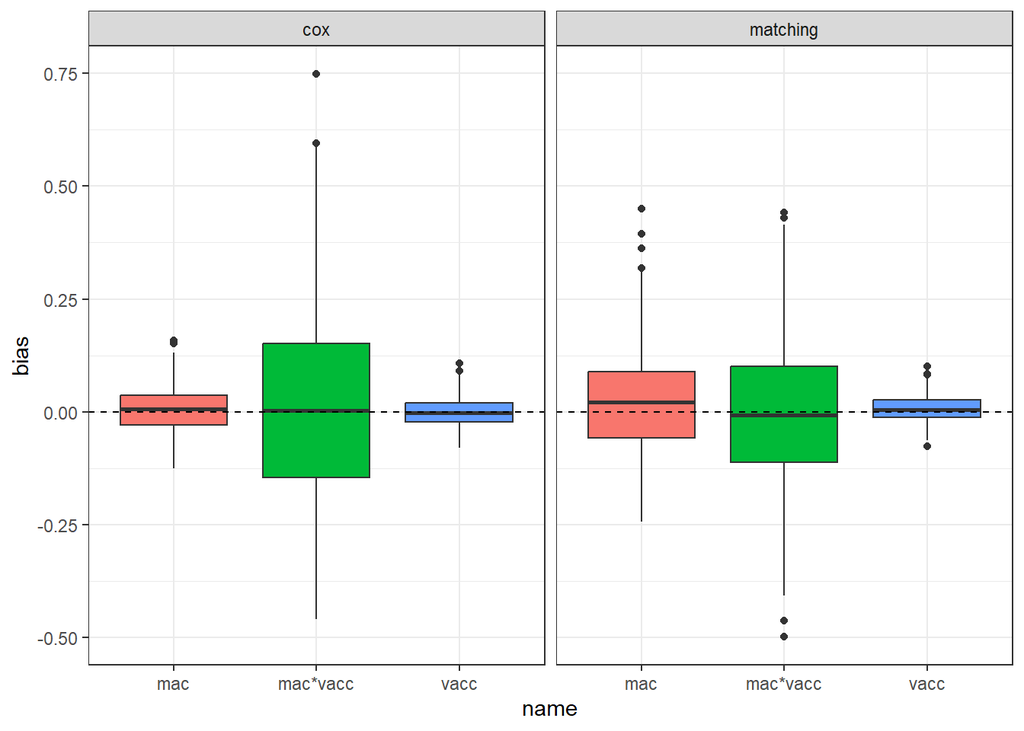

# Time-Fixed Confounder

Hier wird die obige Simulation erweitert, indem ein zeitunabhängiger Confounder (Sex) hnzugefügt wird. Dieser hat einen direkten kausalen Einfluss auf die Impfwahrscheinlichkeit und auf die Wahrscheinlichkeit Influenza zu bekommen.

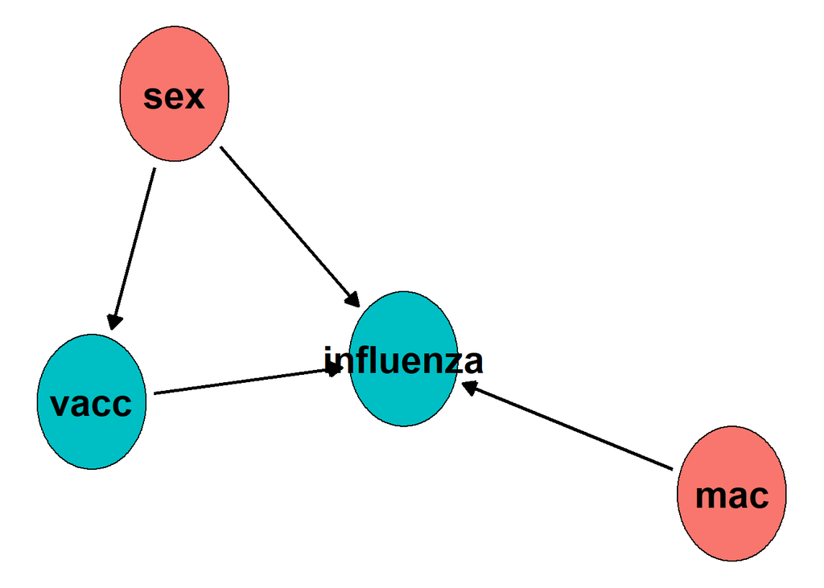

```r
prob_influ <- function(data, base_p, rr_mac, rr_vacc_mac, rr_vacc_nonmac,
                       rr_sex) {
  base_p * rr_mac^(data$mac) * rr_vacc_mac^(data$mac & data$vacc_event) *
    rr_vacc_nonmac^(data$vacc_event & !data$mac) * rr_sex^(data$sex)
}

prob_vacc <- function(data, base_p, rr_sex) {
  base_p * rr_sex^(data$sex)
}

dag <- empty_dag() +
  node("mac", type="rbernoulli", p=0.2) +
  node("sex", type="rbernoulli", p=0.5) +
  node_td("vacc", type="time_to_event", prob_fun=prob_vacc,
          event_duration=Inf, parents="sex", base_p=0.0005,
          rr_sex=5) +
  node_td("influenza", type="time_to_event", prob_fun=prob_influ,
          event_duration=20, parents=c("mac", "vacc_event", "sex"),
          base_p=0.001, rr_mac=1.5, rr_vacc_mac=0.8, rr_vacc_nonmac=0.5,
          rr_sex=4)
plot(dag)
```

```r
summary(dag)
```

```
## A DAG object using the following structural equations:
##
##          mac ~ Bernoulli(0.2)
##          sex ~ Bernoulli(0.5)
##      vacc(t) ~ Bernoulli(prob_vacc(base_p, rr_sex, sex(t)))
## influenza(t) ~ Bernoulli(prob_influ(base_p, rr_mac, rr_vacc_mac, rr_vacc_nonmac, rr_sex, mac(t), vacc_event(t), sex(t)))
```

## Cox Beispiel (ohne Adjustierung)

```
## Call:
## coxph(formula = Surv(start, stop, influenza) ~ mac + vacc + mac *
##     vacc, data = dmod)
##
##   n= 123769, number of events= 51876
##
##                      coef exp(coef) se(coef)      z Pr(>|z|)
## macTRUE           0.35153   1.42125  0.01119 31.420  < 2e-16 ***
## vaccTRUE         -0.11860   0.88816  0.01454 -8.159 3.38e-16 ***
## macTRUE:vaccTRUE  0.41662   1.51683  0.02727 15.278  < 2e-16 ***
## ---
## Signif. codes:  0 '***' 0.001 '**' 0.01 '*' 0.05 '.' 0.1 ' ' 1
##
##                  exp(coef) exp(-coef) lower .95 upper .95
## macTRUE             1.4212     0.7036    1.3904    1.4528
## vaccTRUE            0.8882     1.1259    0.8632    0.9138
## macTRUE:vaccTRUE    1.5168     0.6593    1.4379    1.6001
##
## Concordance= 0.54  (se = 0.001 )
## Likelihood ratio test= 1770  on 3 df,   p=<2e-16
## Wald test            = 1941  on 3 df,   p=<2e-16
## Score (logrank) test = 1985  on 3 df,   p=<2e-16
```

## Cox Beispiel (mit Adjustierung)

```
## Call:
## coxph(formula = Surv(start, stop, influenza) ~ mac + vacc + mac *
##     vacc + sex, data = dmod)
##
##   n= 123769, number of events= 51876
##
##                       coef exp(coef)  se(coef)      z Pr(>|z|)
## macTRUE           0.411283  1.508752  0.011204  36.71   <2e-16 ***
## vaccTRUE         -0.684235  0.504476  0.015004 -45.60   <2e-16 ***
## sexTRUE           1.375661  3.957690  0.009989 137.72   <2e-16 ***
## macTRUE:vaccTRUE  0.462183  1.587536  0.027276  16.95   <2e-16 ***
## ---
## Signif. codes:  0 '***' 0.001 '**' 0.01 '*' 0.05 '.' 0.1 ' ' 1
##
##                  exp(coef) exp(-coef) lower .95 upper .95
## macTRUE             1.5088     0.6628    1.4760    1.5423
## vaccTRUE            0.5045     1.9823    0.4899    0.5195
## sexTRUE             3.9577     0.2527    3.8810    4.0359
## macTRUE:vaccTRUE    1.5875     0.6299    1.5049    1.6747
##
## Concordance= 0.675  (se = 0.001 )
## Likelihood ratio test= 22496  on 4 df,   p=<2e-16
## Wald test            = 20992  on 4 df,   p=<2e-16
## Score (logrank) test = 23230  on 4 df,   p=<2e-16
```

## Matching Beispiel

```
## Call:
## coxph(formula = Surv(event_time, status) ~ mac + .treat + mac *
##     .treat + sex, data = d_match)
##
##   n= 71824, number of events= 24133
##
##                        coef exp(coef) se(coef)      z Pr(>|z|)
## macTRUE             0.41480   1.51407  0.02025  20.49   <2e-16 ***
## .treatTRUE         -0.67423   0.50955  0.01534 -43.95   <2e-16 ***
## sexTRUE             1.41245   4.10599  0.02240  63.07   <2e-16 ***
## macTRUE:.treatTRUE  0.46846   1.59753  0.02925  16.01   <2e-16 ***
## ---
## Signif. codes:  0 '***' 0.001 '**' 0.01 '*' 0.05 '.' 0.1 ' ' 1
##
##                    exp(coef) exp(-coef) lower .95 upper .95
## macTRUE               1.5141     0.6605    1.4552    1.5754
## .treatTRUE            0.5095     1.9625    0.4945    0.5251
## sexTRUE               4.1060     0.2435    3.9297    4.2902
## macTRUE:.treatTRUE    1.5975     0.6260    1.5085    1.6918
##
## Concordance= 0.662  (se = 0.002 )
## Likelihood ratio test= 8872  on 4 df,   p=<2e-16
## Wald test            = 7217  on 4 df,   p=<2e-16
## Score (logrank) test = 7920  on 4 df,   p=<2e-16
```

## Monte-Carlo Vergleich

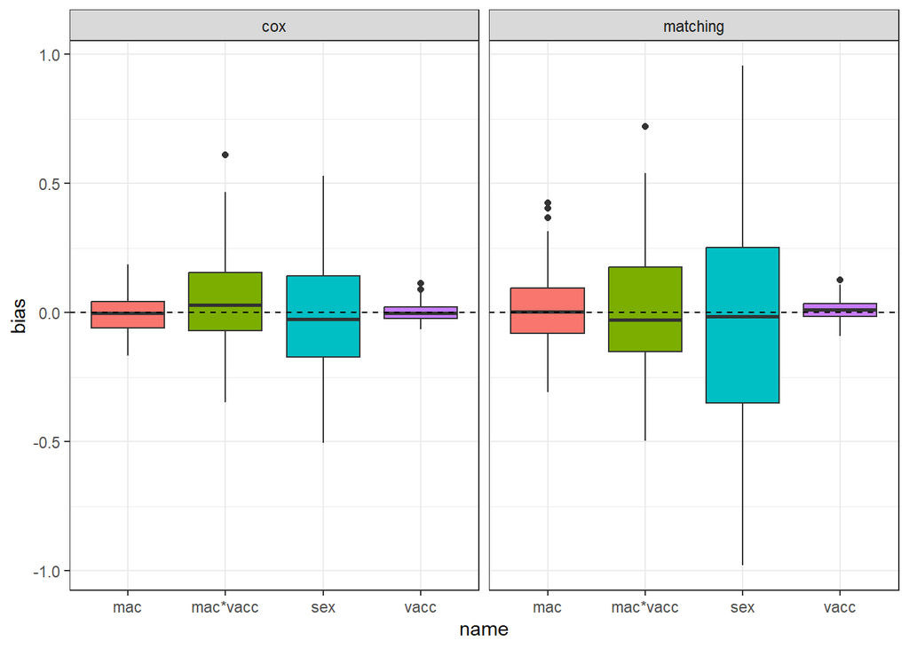

# Time-Varying Confounder

Hier wird statt einem zeitunabhängigem Confounder ein zeitabhängiger Confounder mit simuliert. Auch dieser erhöht sowohl die Wahrscheinlichkeit geimpft zu werden, als auch die Wahrscheinlichkeit eine Influenza zu bekommen.

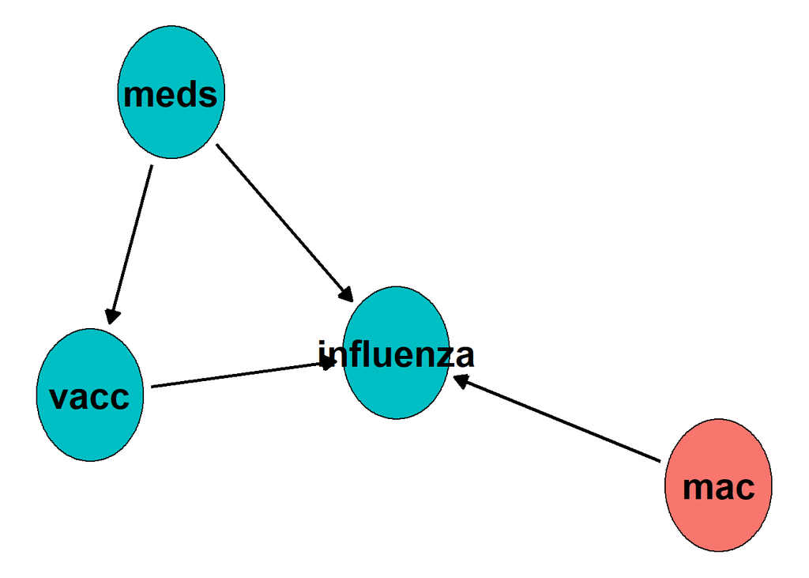

```r
prob_influ <- function(data, base_p, rr_mac, rr_vacc_mac, rr_vacc_nonmac,
                       rr_meds) {
  base_p * rr_mac^(data$mac) * rr_vacc_mac^(data$mac & data$vacc_event) *
    rr_vacc_nonmac^(data$vacc_event & !data$mac) * rr_meds^(data$meds_event)
}

prob_vacc <- function(data, base_p, rr_meds) {
  base_p * rr_meds^(data$meds_event)
}

dag <- empty_dag() +
  node("mac", type="rbernoulli", p=0.2) +
  node_td("meds", type="time_to_event", prob_fun=0.001, event_duration=Inf) +
  node_td("vacc", type="time_to_event", prob_fun=prob_vacc,
          event_duration=Inf, parents="meds_event", base_p=0.0005,
          rr_meds=5) +
  node_td("influenza", type="time_to_event", prob_fun=prob_influ,
          event_duration=20, parents=c("mac", "vacc_event", "meds_event"),
          base_p=0.001, rr_mac=1.5, rr_vacc_mac=0.8, rr_vacc_nonmac=0.5,
          rr_meds=4)
plot(dag)
```

```r
summary(dag)
```

```
## A DAG object using the following structural equations:
##
##          mac ~ Bernoulli(0.2)
##      meds(t) ~ Bernoulli(0.001)
##      vacc(t) ~ Bernoulli(prob_vacc(base_p, rr_meds, meds_event(t)))
## influenza(t) ~ Bernoulli(prob_influ(base_p, rr_mac, rr_vacc_mac, rr_vacc_nonmac, rr_meds, mac(t), vacc_event(t), meds_event(t)))
```

## Cox Beispiel (ohne Adjustierung)

```
## Call:
## coxph(formula = Surv(start, stop, influenza) ~ mac + vacc + mac *
##     vacc, data = dmod)
##
##   n= 143176, number of events= 39627
##
##                      coef exp(coef) se(coef)      z Pr(>|z|)
## macTRUE           0.38700   1.47256  0.01214  31.88   <2e-16 ***
## vaccTRUE         -0.31810   0.72753  0.02117 -15.02   <2e-16 ***
## macTRUE:vaccTRUE  0.42888   1.53554  0.03805  11.27   <2e-16 ***
## ---
## Signif. codes:  0 '***' 0.001 '**' 0.01 '*' 0.05 '.' 0.1 ' ' 1
##
##                  exp(coef) exp(-coef) lower .95 upper .95
## macTRUE             1.4726     0.6791     1.438    1.5080
## vaccTRUE            0.7275     1.3745     0.698    0.7584
## macTRUE:vaccTRUE    1.5355     0.6512     1.425    1.6544
##
## Concordance= 0.545  (se = 0.001 )
## Likelihood ratio test= 1552  on 3 df,   p=<2e-16
## Wald test            = 1611  on 3 df,   p=<2e-16
## Score (logrank) test = 1642  on 3 df,   p=<2e-16
```

## Cox Beispiel (mit Adjustierung)

```
## Call:
## coxph(formula = Surv(start, stop, influenza) ~ mac + vacc + mac *
##     vacc + meds, data = dmod)
##
##   n= 143176, number of events= 39627
##
##                      coef exp(coef) se(coef)      z Pr(>|z|)
## macTRUE           0.40400   1.49780  0.01214  33.27   <2e-16 ***
## vaccTRUE         -0.69447   0.49934  0.02148 -32.34   <2e-16 ***
## medsTRUE          1.40571   4.07841  0.01138 123.47   <2e-16 ***
## macTRUE:vaccTRUE  0.48979   1.63198  0.03805  12.87   <2e-16 ***
## ---
## Signif. codes:  0 '***' 0.001 '**' 0.01 '*' 0.05 '.' 0.1 ' ' 1
##
##                  exp(coef) exp(-coef) lower .95 upper .95
## macTRUE             1.4978     0.6676    1.4626    1.5339
## vaccTRUE            0.4993     2.0026    0.4788    0.5208
## medsTRUE            4.0784     0.2452    3.9884    4.1704
## macTRUE:vaccTRUE    1.6320     0.6128    1.5147    1.7583
##
## Concordance= 0.63  (se = 0.001 )
## Likelihood ratio test= 14329  on 4 df,   p=<2e-16
## Wald test            = 16791  on 4 df,   p=<2e-16
## Score (logrank) test = 18640  on 4 df,   p=<2e-16
```

## Matching Beispiel (ohne Adjustierung)

```
## Call:
## coxph(formula = Surv(event_time, status) ~ .treat + mac + .treat *
##     mac, data = d_match)
##
##   n= 46844, number of events= 9435
##
##                        coef exp(coef) se(coef)       z Pr(>|z|)
## .treatTRUE         -0.27047   0.76302  0.02457 -11.009   <2e-16 ***
## macTRUE             0.40650   1.50155  0.03284  12.377   <2e-16 ***
## .treatTRUE:macTRUE  0.43634   1.54704  0.04549   9.593   <2e-16 ***
## ---
## Signif. codes:  0 '***' 0.001 '**' 0.01 '*' 0.05 '.' 0.1 ' ' 1
##
##                    exp(coef) exp(-coef) lower .95 upper .95
## .treatTRUE             0.763     1.3106    0.7272    0.8007
## macTRUE                1.502     0.6660    1.4079    1.6014
## .treatTRUE:macTRUE     1.547     0.6464    1.4151    1.6913
##
## Concordance= 0.576  (se = 0.003 )
## Likelihood ratio test= 834.9  on 3 df,   p=<2e-16
## Wald test            = 891.1  on 3 df,   p=<2e-16
## Score (logrank) test = 926  on 3 df,   p=<2e-16
```

## Matching Beispiel (mit Adjustierung, ohne Matching für meds)

```
## Call:
## coxph(formula = Surv(event_time, status) ~ .treat + mac + .treat *
##     mac + meds, data = d_match)
##
##   n= 46844, number of events= 9435
##
##                        coef exp(coef) se(coef)      z Pr(>|z|)
## .treatTRUE         -0.64637   0.52394  0.02614 -24.72   <2e-16 ***
## macTRUE             0.42899   1.53571  0.03285  13.06   <2e-16 ***
## medsTRUE            1.20788   3.34639  0.02365  51.08   <2e-16 ***
## .treatTRUE:macTRUE  0.46050   1.58486  0.04549  10.12   <2e-16 ***
## ---
## Signif. codes:  0 '***' 0.001 '**' 0.01 '*' 0.05 '.' 0.1 ' ' 1
##
##                    exp(coef) exp(-coef) lower .95 upper .95
## .treatTRUE            0.5239     1.9086    0.4978    0.5515
## macTRUE               1.5357     0.6512    1.4399    1.6378
## medsTRUE              3.3464     0.2988    3.1948    3.5052
## .treatTRUE:macTRUE    1.5849     0.6310    1.4497    1.7327
##
## Concordance= 0.663  (se = 0.003 )
## Likelihood ratio test= 3233  on 4 df,   p=<2e-16
## Wald test            = 3458  on 4 df,   p=<2e-16
## Score (logrank) test = 3629  on 4 df,   p=<2e-16
```

## Matching Beispiel (mit Adjustierung, mit Matching für meds)

```
## Call:
## coxph(formula = Surv(event_time, status) ~ .treat + mac + .treat *
##     mac, data = d_match)
##
##   n= 46844, number of events= 10572
##
##                        coef exp(coef) se(coef)      z Pr(>|z|)
## .treatTRUE         -0.59475   0.55170  0.02349 -25.32   <2e-16 ***
## macTRUE             0.36869   1.44583  0.02955  12.48   <2e-16 ***
## .treatTRUE:macTRUE  0.45185   1.57122  0.04354  10.38   <2e-16 ***
## ---
## Signif. codes:  0 '***' 0.001 '**' 0.01 '*' 0.05 '.' 0.1 ' ' 1
##
##                    exp(coef) exp(-coef) lower .95 upper .95
## .treatTRUE            0.5517     1.8126    0.5269    0.5777
## macTRUE               1.4458     0.6916    1.3645    1.5320
## .treatTRUE:macTRUE    1.5712     0.6364    1.4427    1.7112
##
## Concordance= 0.597  (se = 0.003 )
## Likelihood ratio test= 1316  on 3 df,   p=<2e-16
## Wald test            = 1264  on 3 df,   p=<2e-16
## Score (logrank) test = 1327  on 3 df,   p=<2e-16
```

## Monte-Carlo Vergleich

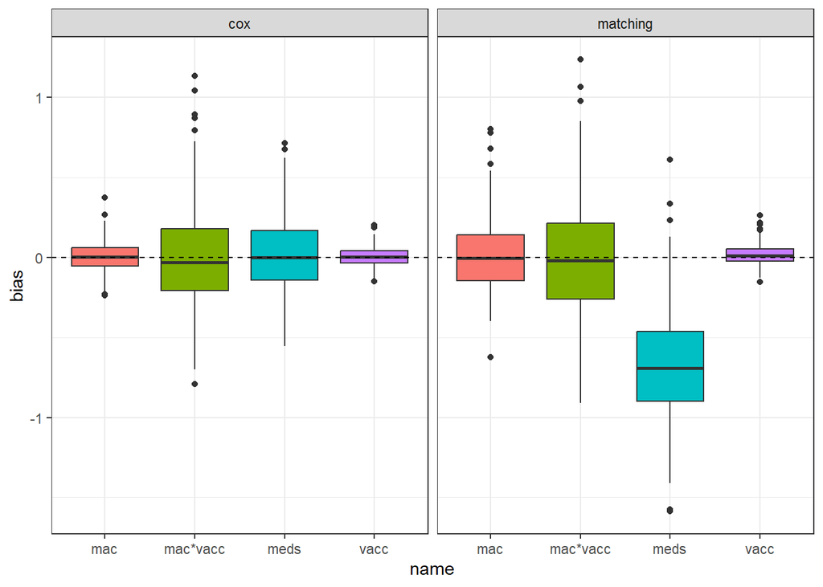

Was hier auffällt ist, dass das HR des zeitabhängigen Confounders beim Matching unterschätzt wird. Das liegt daran, dass dieser nur als zeitunabhängige Variable mit ins Modell geht. Sprich, wenn eine Person zum Studieneinschluss noch FALSE bei dieser Variable hatte, aber zu einem späteren Zeitpunkt TRUE hat, wird dies nicht berücksichtigt. Damit gehen einige Zeiträume mit erhöhtem Risiko durch “meds” als Zeiträume unter nicht-“meds” in das Modell ein. Das hat (wie in der Simulation zu sehen ist) aber keinen Einfluss auf die korrekte Schätzung der relevanten HRs. Das Confounding wird korrekt weg-adjustiert, wie erwartet. Nur der Effekt der “meds” selbst ist verzerrt.

# Treatment-Confounder Feedback

Wenn treatment-confounder feedback existiert und man schlicht ein einfaches Cox Modell mit start-stop Daten verwendet, wird ein teil des totalen kausalen Effekts weg-adjustiert: nämlich der indirekte Effekt der über die Variable geht welche sowohl Confounder als auch Mediator ist. Dieses Problem sollte beim zeitabhängigen Matching nicht vorliegen. Demnach müssten sich die HRs der beiden Methoden unterscheiden. Dies wird zunächst hier überprüft.

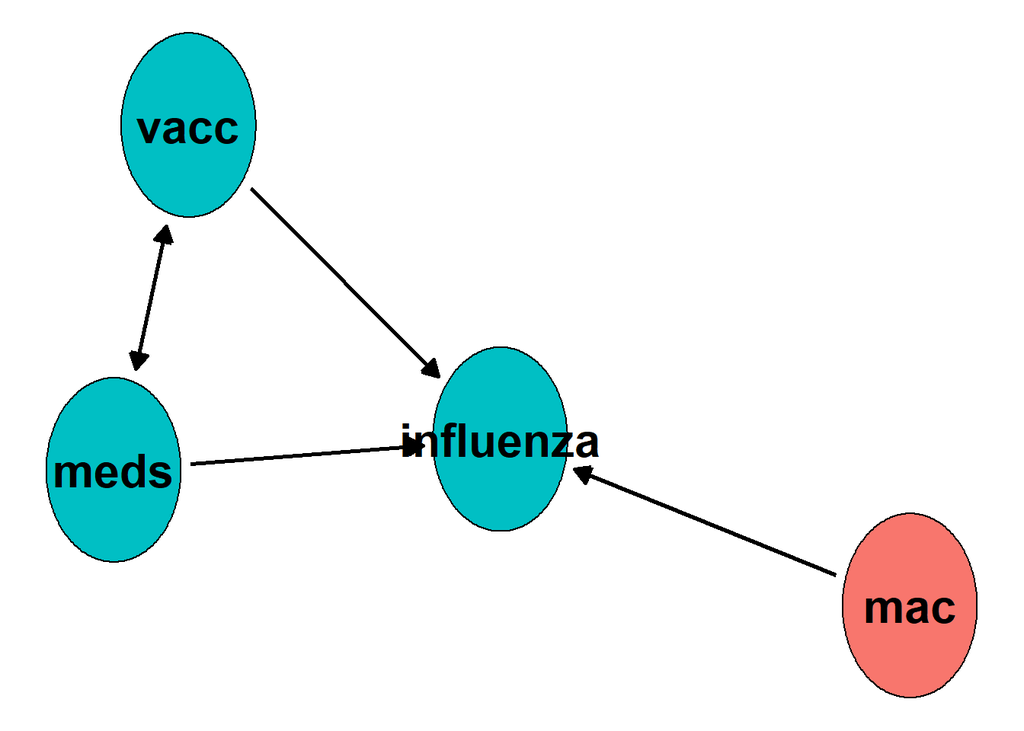

```r
prob_influ <- function(data, base_p, rr_mac, rr_vacc_mac, rr_vacc_nonmac,
                       rr_meds) {
  base_p * rr_mac^(data$mac) * rr_vacc_mac^(data$mac & data$vacc_event) *
    rr_vacc_nonmac^(data$vacc_event & !data$mac) * rr_meds^(data$meds_event)
}

prob_vacc <- function(data, base_p, rr_meds) {
  base_p * rr_meds^(data$meds_event)
}

prob_meds <- function(data, base_p, rr_vacc) {
  base_p * rr_vacc^(data$vacc_event)
}

dag <- empty_dag() +
  node("mac", type="rbernoulli", p=0.2) +
  node_td("meds", type="time_to_event", prob_fun=prob_meds,
          event_duration=Inf, parents="vacc_event", base_p=0.001,
          rr_vacc=4) +
  node_td("vacc", type="time_to_event", prob_fun=prob_vacc,
          event_duration=Inf, parents="meds_event", base_p=0.0005,
          rr_meds=5) +
  node_td("influenza", type="time_to_event", prob_fun=prob_influ,
          event_duration=20, parents=c("mac", "vacc_event", "meds_event"),
          base_p=0.001, rr_mac=1.5, rr_vacc_mac=0.8, rr_vacc_nonmac=0.5,
          rr_meds=4)
plot(dag)
```

```r
summary(dag)
```

```
## A DAG object using the following structural equations:
##
##          mac ~ Bernoulli(0.2)
##      meds(t) ~ Bernoulli(prob_meds(base_p, rr_vacc, vacc_event(t)))
##      vacc(t) ~ Bernoulli(prob_vacc(base_p, rr_meds, meds_event(t)))
## influenza(t) ~ Bernoulli(prob_influ(base_p, rr_mac, rr_vacc_mac, rr_vacc_nonmac, rr_meds, mac(t), vacc_event(t), meds_event(t)))
```

## Cox Beispiel (ohne Adjustierung)

```
## Call:
## coxph(formula = Surv(start, stop, influenza) ~ mac + vacc + mac *
##     vacc, data = dmod)
##
##   n= 146809, number of events= 40484
##
##                      coef exp(coef) se(coef)      z Pr(>|z|)
## macTRUE           0.38699   1.47254  0.01214 31.878  < 2e-16 ***
## vaccTRUE         -0.07858   0.92443  0.01931 -4.069 4.72e-05 ***
## macTRUE:vaccTRUE  0.40508   1.49942  0.03513 11.530  < 2e-16 ***
## ---
## Signif. codes:  0 '***' 0.001 '**' 0.01 '*' 0.05 '.' 0.1 ' ' 1
##
##                  exp(coef) exp(-coef) lower .95 upper .95
## macTRUE             1.4725     0.6791    1.4379    1.5080
## vaccTRUE            0.9244     1.0817    0.8901    0.9601
## macTRUE:vaccTRUE    1.4994     0.6669    1.3996    1.6063
##
## Concordance= 0.539  (se = 0.001 )
## Likelihood ratio test= 1462  on 3 df,   p=<2e-16
## Wald test            = 1608  on 3 df,   p=<2e-16
## Score (logrank) test = 1646  on 3 df,   p=<2e-16
```

## Cox Beispiel (mit Adjustierung)

```
## Call:
## coxph(formula = Surv(start, stop, influenza) ~ mac + vacc + mac *
##     vacc + meds, data = dmod)
##
##   n= 146809, number of events= 40484
##
##                      coef exp(coef) se(coef)      z Pr(>|z|)
## macTRUE           0.40770   1.50336  0.01214  33.57   <2e-16 ***
## vaccTRUE         -0.67709   0.50809  0.02001 -33.84   <2e-16 ***
## medsTRUE          1.38124   3.97983  0.01148 120.29   <2e-16 ***
## macTRUE:vaccTRUE  0.45995   1.58400  0.03513  13.09   <2e-16 ***
## ---
## Signif. codes:  0 '***' 0.001 '**' 0.01 '*' 0.05 '.' 0.1 ' ' 1
##
##                  exp(coef) exp(-coef) lower .95 upper .95
## macTRUE             1.5034     0.6652    1.4680    1.5396
## vaccTRUE            0.5081     1.9682    0.4886    0.5284
## medsTRUE            3.9798     0.2513    3.8913    4.0704
## macTRUE:vaccTRUE    1.5840     0.6313    1.4786    1.6969
##
## Concordance= 0.627  (se = 0.001 )
## Likelihood ratio test= 13782  on 4 df,   p=<2e-16
## Wald test            = 16075  on 4 df,   p=<2e-16
## Score (logrank) test = 17563  on 4 df,   p=<2e-16
```

## Matching Beispiel (ohne Adjustierung)

```
## Call:
## coxph(formula = Surv(event_time, status) ~ .treat + mac + .treat *
##     mac, data = d_match)
##
##   n= 46512, number of events= 10198
##
##                        coef exp(coef) se(coef)      z Pr(>|z|)
## .treatTRUE         -0.10615   0.89929  0.02340 -4.536 5.73e-06 ***
## macTRUE             0.36136   1.43528  0.03304 10.939  < 2e-16 ***
## .treatTRUE:macTRUE  0.45078   1.56954  0.04435 10.164  < 2e-16 ***
## ---
## Signif. codes:  0 '***' 0.001 '**' 0.01 '*' 0.05 '.' 0.1 ' ' 1
##
##                    exp(coef) exp(-coef) lower .95 upper .95
## .treatTRUE            0.8993     1.1120     0.859    0.9415
## macTRUE               1.4353     0.6967     1.345    1.5313
## .treatTRUE:macTRUE    1.5695     0.6371     1.439    1.7121
##
## Concordance= 0.566  (se = 0.003 )
## Likelihood ratio test= 780.7  on 3 df,   p=<2e-16
## Wald test            = 880.2  on 3 df,   p=<2e-16
## Score (logrank) test = 917.3  on 3 df,   p=<2e-16
```

## Matching Beispiel (mit Adjustierung)

```
## Call:
## coxph(formula = Surv(event_time, status) ~ .treat + mac + .treat *
##     mac + meds, data = d_match)
##
##   n= 46512, number of events= 10198
##
##                        coef exp(coef) se(coef)      z Pr(>|z|)
## .treatTRUE         -0.39597   0.67303  0.02486 -15.93   <2e-16 ***
## macTRUE             0.37552   1.45574  0.03304  11.37   <2e-16 ***
## medsTRUE            0.95457   2.59755  0.02304  41.44   <2e-16 ***
## .treatTRUE:macTRUE  0.47970   1.61558  0.04436  10.81   <2e-16 ***
## ---
## Signif. codes:  0 '***' 0.001 '**' 0.01 '*' 0.05 '.' 0.1 ' ' 1
##
##                    exp(coef) exp(-coef) lower .95 upper .95
## .treatTRUE             0.673     1.4858     0.641    0.7066
## macTRUE                1.456     0.6869     1.364    1.5531
## medsTRUE               2.598     0.3850     2.483    2.7175
## .treatTRUE:macTRUE     1.616     0.6190     1.481    1.7623
##
## Concordance= 0.637  (se = 0.003 )
## Likelihood ratio test= 2372  on 4 df,   p=<2e-16
## Wald test            = 2611  on 4 df,   p=<2e-16
## Score (logrank) test = 2717  on 4 df,   p=<2e-16
```

## Monte-Carlo Vergleich

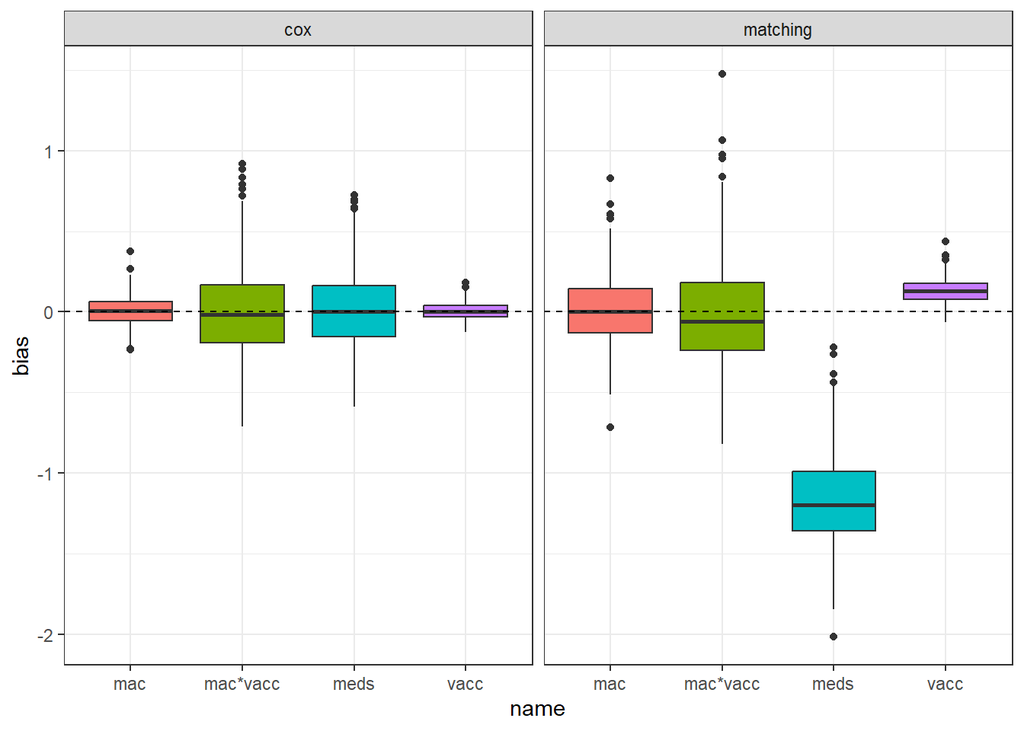